# Predicting Bexar County Property Vaues

### Changes

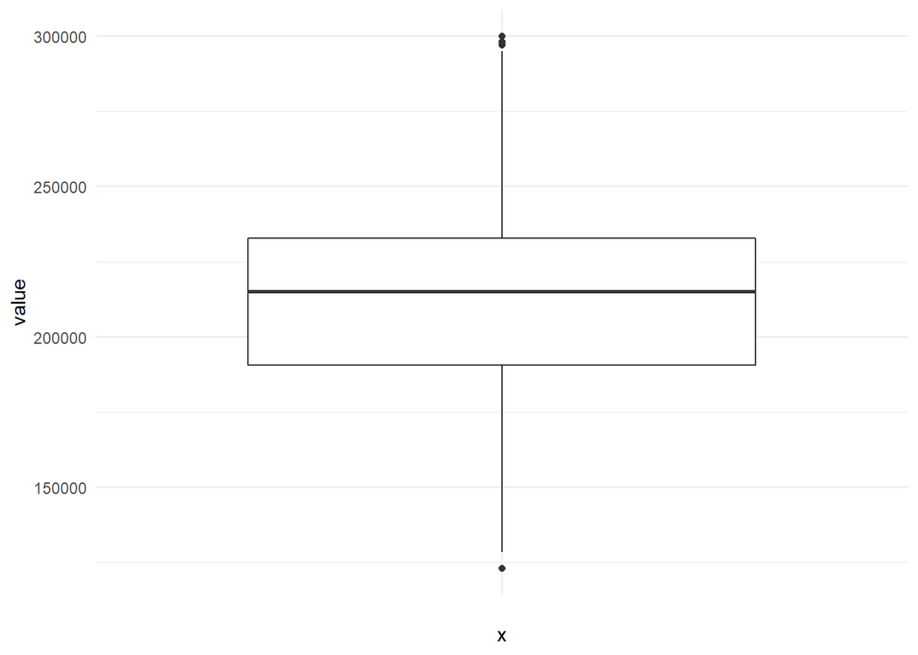

```r
# define df29, df28
# change binary variables, delete outlier property_ids, remove property_id as predictor
df <- build_data

df29 <- df %>%
  mutate(RMS = as.factor(RMS), # change binary variables to factors
         SPA = as.factor(SPA)) %>%
  filter(!property_id %in% c(1010,1567,1568))  #remove outliers

df28 <- df %>%
  mutate(RMS = as.factor(RMS), # change binary variables to factors
         SPA = as.factor(SPA)) %>%
  filter(!property_id %in% c(1010,1567,1568)) %>%  #remove outliers
  select(-property_id) # property_id not useful in predicting value

# df12 & df10 defined after nzv() next chunk

ggplot(df29,aes(x="",y=value)) + geom_boxplot() + theme_minimal() # examine outliers
```

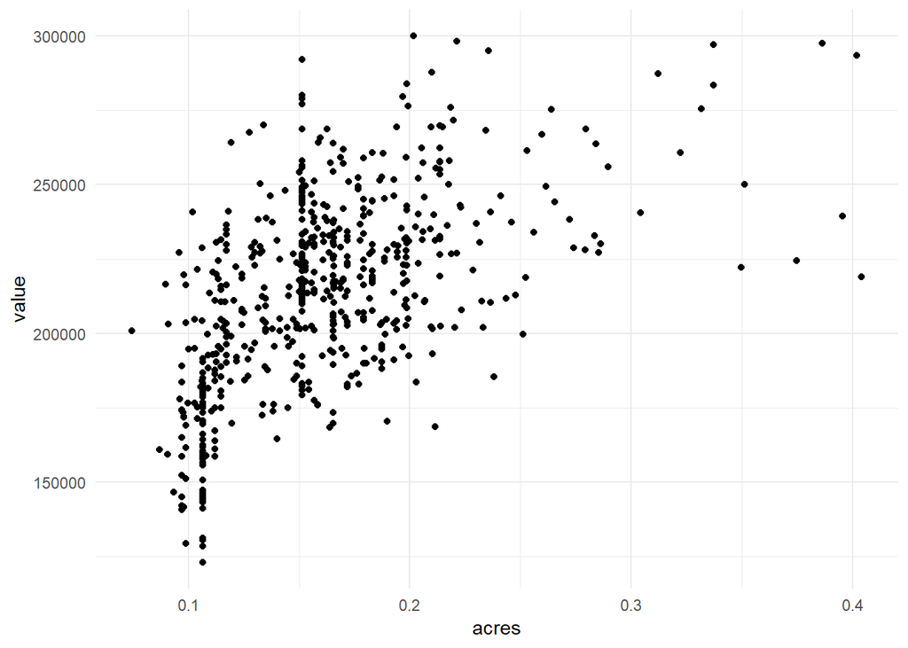

```r
ggplot(df29,aes(x=acres,y=value)) + geom_point() + theme_minimal()
```

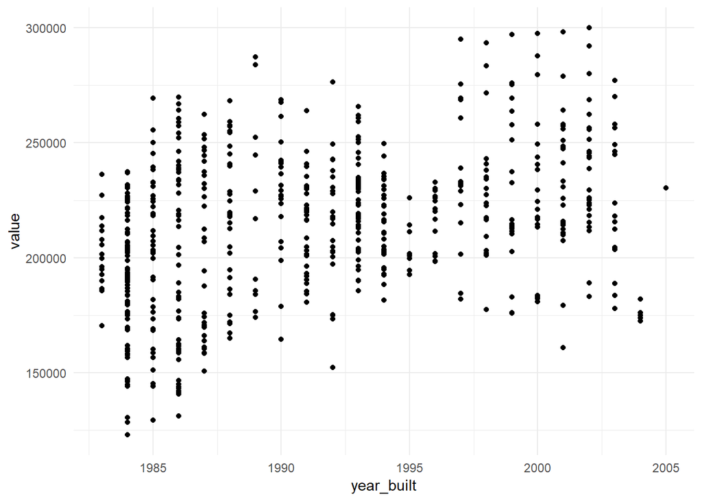

```r
ggplot(df29,aes(x=year_built,y=value)) + geom_point() + theme_minimal()
```

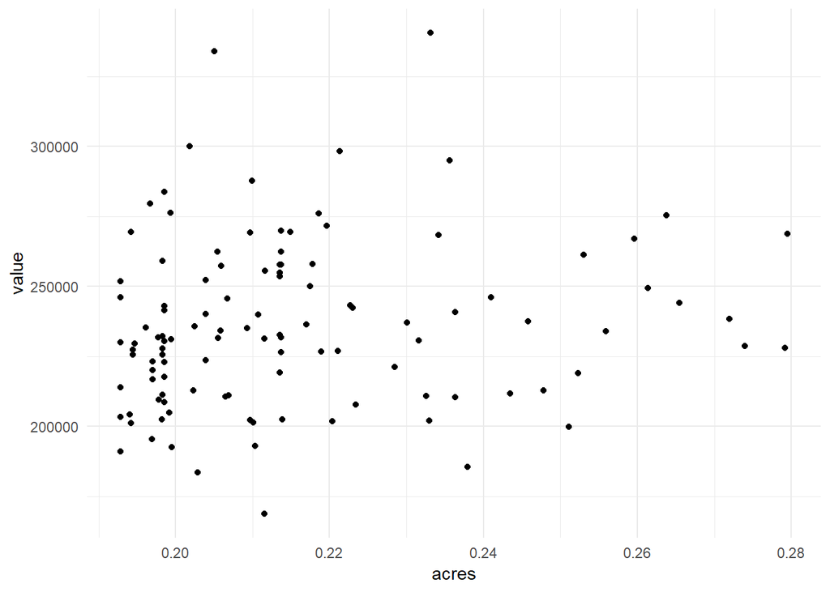

```r
# property_id==1567,1568 are anaomolies
# houses with 35k-70k difference in value from similar houses
acres_df <- build_data %>% filter(acres<=0.28, acres>=0.19) %>% arrange(desc(value))
ggplot(acres_df,aes(x=acres,y=value)) + geom_point() + theme_minimal()
```

### Degenerate variables

```r
# check for degenerate variables
vars_nzv <- nearZeroVar(df)
# keep binary variables, SPA, RMS, column # 17,20
vars_nzv <- vars_nzv[-11]
vars_nzv <- vars_nzv[-13]
df_new <- df[,-vars_nzv]
dim(df) #29
```

```
## [1] 608  30
```

```r
dim(df_new) #13
```

```
## [1] 608  14
```

```r
pred_vars <- names(df_new)
length(pred_vars) #-property_id,-value
```

```
## [1] 14
```

```r
pred_vars
```

```
##  [1] "property_id" "AG"          "DCK"         "LA"          "LA2"
##  [6] "OP"          "PA"          "RMS"         "SPA"         "year_built"
## [11] "acres"       "eff_front"   "eff_depth"   "value"
```

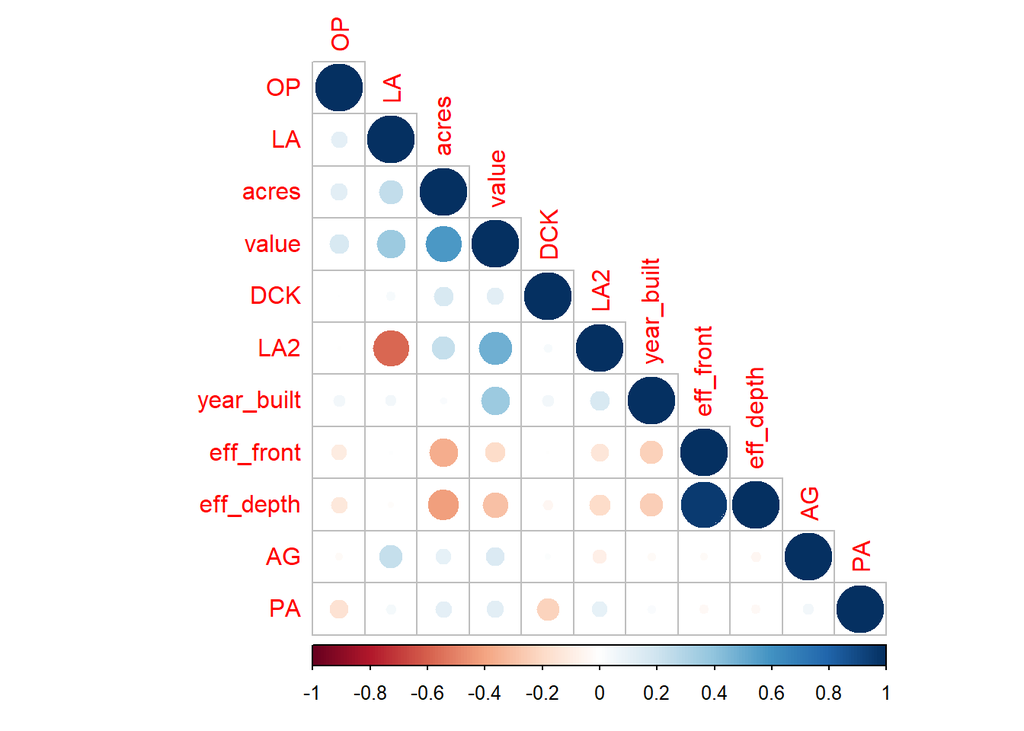

```
##               AG   DCK    LA   LA2    OP    PA year_built acres eff_front
## AG          1.00  0.02  0.24 -0.09 -0.03  0.05      -0.03  0.11     -0.03
## DCK         0.02  1.00  0.04  0.03  0.00 -0.22       0.06  0.17     -0.01
## LA          0.24  0.04  1.00 -0.57  0.12  0.04       0.05  0.25      0.01
## LA2        -0.09  0.03 -0.57  1.00 -0.01  0.10       0.16  0.24     -0.14
## OP         -0.03  0.00  0.12 -0.01  1.00 -0.15       0.06  0.12     -0.10
## PA          0.05 -0.22  0.04  0.10 -0.15  1.00       0.03  0.12     -0.04
## year_built -0.03  0.06  0.05  0.16  0.06  0.03       1.00  0.02     -0.24
## acres       0.11  0.17  0.25  0.24  0.12  0.12       0.02  1.00     -0.37
## eff_front  -0.03 -0.01  0.01 -0.14 -0.10 -0.04      -0.24 -0.37      1.00
## eff_depth  -0.04 -0.04 -0.02 -0.19 -0.12 -0.04      -0.24 -0.42      0.95
## value       0.16  0.12  0.36  0.49  0.17  0.13       0.37  0.57     -0.18
##            eff_depth value
## AG             -0.04  0.16
## DCK            -0.04  0.12
## LA             -0.02  0.36
## LA2            -0.19  0.49
## OP             -0.12  0.17
## PA             -0.04  0.13
## year_built     -0.24  0.37
## acres          -0.42  0.57
## eff_front       0.95 -0.18
## eff_depth       1.00 -0.29
## value          -0.29  1.00
```

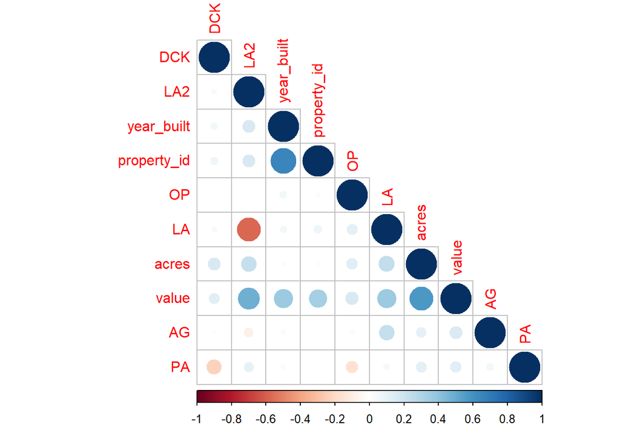

```
##                AG   DCK    LA   LA2    OP    PA year_built acres
## AG           1.00  0.02  0.24 -0.09 -0.03  0.05      -0.03  0.11
## DCK          0.02  1.00  0.04  0.03  0.00 -0.22       0.06  0.17
## LA           0.24  0.04  1.00 -0.57  0.12  0.04       0.05  0.25
## LA2         -0.09  0.03 -0.57  1.00 -0.01  0.10       0.16  0.24
## OP          -0.03  0.00  0.12 -0.01  1.00 -0.15       0.06  0.12
## PA           0.05 -0.22  0.04  0.10 -0.15  1.00       0.03  0.12
## year_built  -0.03  0.06  0.05  0.16  0.06  0.03       1.00  0.02
## acres        0.11  0.17  0.25  0.24  0.12  0.12       0.02  1.00
## property_id -0.01  0.06  0.07  0.16  0.03  0.00       0.66 -0.02
## value        0.16  0.12  0.36  0.49  0.17  0.13       0.37  0.57
##             property_id value
## AG                -0.01  0.16
## DCK                0.06  0.12
## LA                 0.07  0.36
## LA2                0.16  0.49
## OP                 0.03  0.17
## PA                 0.00  0.13
## year_built         0.66  0.37
## acres             -0.02  0.57
## property_id        1.00  0.34
## value              0.34  1.00
```

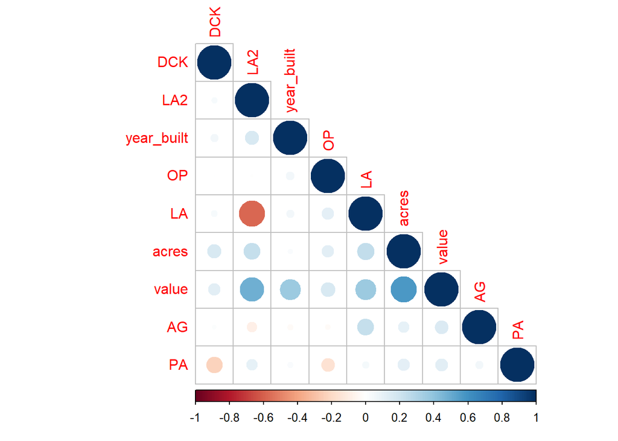

```
##               AG   DCK    LA   LA2    OP    PA year_built acres value
## AG          1.00  0.02  0.24 -0.09 -0.03  0.05      -0.03  0.11  0.16
## DCK         0.02  1.00  0.04  0.03  0.00 -0.22       0.06  0.17  0.12
## LA          0.24  0.04  1.00 -0.57  0.12  0.04       0.05  0.25  0.36
## LA2        -0.09  0.03 -0.57  1.00 -0.01  0.10       0.16  0.24  0.49
## OP         -0.03  0.00  0.12 -0.01  1.00 -0.15       0.06  0.12  0.17
## PA          0.05 -0.22  0.04  0.10 -0.15  1.00       0.03  0.12  0.13
## year_built -0.03  0.06  0.05  0.16  0.06  0.03       1.00  0.02  0.37
## acres       0.11  0.17  0.25  0.24  0.12  0.12       0.02  1.00  0.57
## value       0.16  0.12  0.36  0.49  0.17  0.13       0.37  0.57  1.00
```

```r
# started with 29 predictors, now have 12 (-value,-property_id):
# AG, DCK, LA, LA2, OP, PA, RMS, SPA, year_built, acres, eff_front, eff_depth, property_id

# predictor variables after removing degenerate variables
df12 <- df28 %>% select('AG','DCK','LA','LA2','OP','PA','RMS','SPA','year_built',
                        'acres','eff_front','eff_depth','value')

df10 <- df12 %>% select(-eff_depth,-eff_front)

df11 <- df29 %>% select('AG','DCK','LA','LA2','OP','PA','RMS','SPA','year_built',
                        'acres','property_id','value')

# look at correlation plots again
# using default pearson correlation
for (i in list(df12,df11,df10)){
  df_corr <- i %>% select(-RMS,-SPA)
  correlations <- cor(df_corr)
  corrplot::corrplot(correlations,order='hclust',type='lower',tl.cex=1)
  print(round(cor(df_corr),digits = 2))
}
```

```r
# notes
# LA, LA2 moderately negatively correlated (r=-0.57)
# eff_depth, eff_front highly positively (r=0.95)correlated and removed in df10 models


rm(df_new,vars_nzv,pred_vars,df_corr,correlations)
```

### Removing predictors & imputing values

```r
# tried both of these, they did not impact model performance

# based on first linear, rf models removing: DCK,PA,RMS1 (not signifcant and low importance)
# df <- df %>% select(-DCK,-PA,-RMS)

# imputing eff_front, eff_depth
# # tried: this did not impact model performance
# # impute missing values in eff_front,eff_depth
# df <- df %>% mutate(eff_front=ifelse(eff_front==0,NA,eff_front),
#                     eff_depth=ifelse(eff_depth==0,NA,eff_depth))
#
# df_prepro <- df %>% select(-value)
# preprocess_vals <- preProcess(df_prepro, method = c("spatialSign"))
# df_impute <- predict(preprocess_vals,df_prepro)
# df <- df_impute
```

## Sample Selection - Generate a Training and Test Set

```r
# function to split data, some models will not run with degenerate variables
split.data <- function(df){

  set.seed(775546)
  train_idx <- createDataPartition(df$value, p=0.75, list=FALSE)

  df_train <- df[train_idx,]
  df_test <- df[-train_idx,]

  out = list()
  out$train_pred = df_train %>% select(-value)
  out$train_resp = df_train %>% select(value)
  out$test_pred = df_test %>% select(-value)
  out$test_resp = df_test %>% select(value)

  return(out)
}
```

## Model Building / Training / Tuning

```r
# get to evaluate performance measure like RMSE
mean_value <- mean(df29$value)
median_value <- median(df29$value)
n_train <- ceiling(nrow(df29) *.75)
n_test <- nrow(df29) - n_train

# define functions to calculate model performance
MSE <- function(error) {mean(error^2)}
RMSE <- function(error) {sqrt(mean(error^2))}
MAE <- function(error) {mean(abs(error))}
R2 <- function(error,df) {1-(sum(error^2)/sum((df$value-mean(df$value))^2))} #specify df # aR2 <- function(error,df,k,n) {(R2(error,df))-(((k-1)/(n-k))*(1-R2(error,df)))} #specify df

# define list of dataframes and placeholders to store model performance
toModelList <- list(df29,df28,df12,df10,df11)
y <- length(toModelList)
df_results <- data.frame(mse_train=rep(NA,y),rmse_train=rep(NA,y),
                          mae_train=rep(NA,y), r2_train=rep(NA,y),
                          rmsesd_train=rep(NA,y), mse_test=rep(NA,y),
                          rmse_test=rep(NA,y), mae_test=rep(NA,y),
                          r2_test=rep(NA,y), model=rep(NA,y),
                          num_pred=c(29,28,12,10,11))

# define function
tune.length.fn = function (k_pred){

  k = ifelse(k_pred==29,28,
     ifelse(k_pred==28,27,
            ifelse(k_pred==12,11,
                   ifelse(k_pred==10,9,6))))
  return(k)
}
```

### Linear Model Fn

```r
# define linear model function
mod.lm.fn <- function(mod_results,dfList) {

  # dfList= toModelList #debug
  # mod_results = df_results #debug

  # define model type
  mod_results$model=c('LM')

  # iterate through list of dataframes
  for (x in unique(dfList)){

    # x=df10 #debug
    k_pred <- ncol(x)-1
    split = split.data(x) #x=data frame to split data on

    set.seed(289)
    control <- trainControl(method='repeatedcv',number=10) #resampling method
    # control <- trainControl(method='boot',number=25) #resampling method

    tuneLength.num = tune.length.fn(k_pred)

    # remove binary predictors
    train_pred_2 <- split$train_pred %>% select(-SPA,-RMS) #train_pred
    test_pred_2 <- split$test_pred %>% select(-SPA,-RMS) #test_pred

    lm_fit <- train(x=train_pred_2, y=split$train_resp$value, method="lm",
                    preProc=c("center","scale"), tuneLength=tuneLength.num,
                    trControl=control) #na.action=na.omit
    # summary(lm_fit)
    # plot(lm_fit$finalModel$fitted.values,lm_fit$finalModel$residuals,main=paste('OLS ',k_pred))

    # train model performance
    mod_results[mod_results$num_pred==k_pred,"mse_train"] = (lm_fit$results$RMSE)^2
    mod_results[mod_results$num_pred==k_pred,"rmse_train"] = lm_fit$results$RMSE
    mod_results[mod_results$num_pred==k_pred,"mae_train"] = lm_fit$results$MAE
    mod_results[mod_results$num_pred==k_pred,"r2_train"] = lm_fit$results$Rsquared
    mod_results[mod_results$num_pred==k_pred,"rmsesd_train"] = c('NA')
    # predict on test set and test model performance
    test_error <- split$test_resp$value - predict(lm_fit,newdata=test_pred_2)
    mod_results[mod_results$num_pred==k_pred,"mse_test"] = MSE(test_error)
    mod_results[mod_results$num_pred==k_pred,"rmse_test"] = RMSE(test_error)
    mod_results[mod_results$num_pred==k_pred,"mae_test"] = MAE(test_error)
    mod_results[mod_results$num_pred==k_pred,"r2_test"] = R2(test_error,split$test_resp)
    # mod_results[mod_results$num_pred==k_pred,"rmsesd_test"] = c('NA')
  }
  # define model value
  return(mod_results)
}
```

### Random Forest Fn

```r
# define RF model function
mod.rf.fn <- function(mod_results,dfList) {

  # define model type
  mod_results$model=c('RF')

  # iterate through list of dataframes
  for (x in unique(dfList)){

    # x=df10 #debug
    k_pred <- ncol(x)-1
    split = split.data(x) #x=data frame to split data on

    set.seed(289)
    control <- trainControl(method='repeatedcv',number=10) #resampling method
    # control <- trainControl(method='boot',number=15) #resampling method

    tuneLength.num = tune.length.fn(k_pred)


    rf_fit = train(x=split$train_pred, y=split$train_resp$value, method = "rf",
                   trControl=control,tuneLength=tuneLength.num,
                   ntree=1000, importance=TRUE) #na.action = na.omit

    mtry <- rf_fit$bestTune[1,1]
    # rf_fit$results
    # plot(rf_fit$) #,main=paste('RF ',k_pred))


    # train model performance
    mod_results[mod_results$num_pred==k_pred,"mse_train"] = (rf_fit$results[rf_fit$results$mtry==mtry,"RMSE"])^2
    mod_results[mod_results$num_pred==k_pred,"rmse_train"] = rf_fit$results[rf_fit$results$mtry==mtry,"RMSE"]
    mod_results[mod_results$num_pred==k_pred,"mae_train"] = rf_fit$results[rf_fit$results$mtry==mtry,"MAE"]
    mod_results[mod_results$num_pred==k_pred,"r2_train"] = rf_fit$results[rf_fit$results$mtry==mtry,"Rsquared"]
    mod_results[mod_results$num_pred==k_pred,"rmsesd_train"] = c('NA')
    # predict on test set and test model performance
    test_error <- split$test_resp$value - predict(rf_fit,newdata=split$test_pred)
    mod_results[mod_results$num_pred==k_pred,"mse_test"] = MSE(test_error)
    mod_results[mod_results$num_pred==k_pred,"rmse_test"] = RMSE(test_error)
    mod_results[mod_results$num_pred==k_pred,"mae_test"] = MAE(test_error)
    mod_results[mod_results$num_pred==k_pred,"r2_test"] = R2(test_error,split$test_resp)
    # mod_results[mod_results$num_pred==k_pred,"rmsesd_test"] = c('NA')
  }
  return(mod_results)
}
```

### GAM Model Fn

```r
# define gam model function
mod.gam.fn <- function(mod_results,dfList) {

  # define model type
  mod_results$model=c('GAM')

  # iterate through list of dataframes
  for (x in unique(dfList)){

    # x=df28 #debug
    k_pred <- ncol(x)-1
    split = split.data(x) #x=data frame to split data on

    set.seed(149)
    control <- trainControl(method='repeatedcv',number=10) #resampling method
    # control <- trainControl(method='boot',number=25) #resampling method

    tuneLength.num = tune.length.fn(k_pred)

    gam_fit <- gam(split$train_resp$value ~., data=split$train_pred, family = 'gaussian')

    # summary(gam_fit)
    # plot(gam_fit$fitted.values,gam_fit$residuals,main=paste('GAM ',k_pred))

    # train model performance
    mod_results[mod_results$num_pred==k_pred,"mse_train"] = MSE(gam_fit$residuals)
    mod_results[mod_results$num_pred==k_pred,"rmse_train"] = RMSE(gam_fit$residuals)
    mod_results[mod_results$num_pred==k_pred,"mae_train"] = MAE(gam_fit$residuals)
    mod_results[mod_results$num_pred==k_pred,"r2_train"] = R2(gam_fit$residuals,split$train_resp)
    mod_results[mod_results$num_pred==k_pred,"rmsesd_train"] = c('NA')
    # predict on test set and test model performance
    test_error <- split$test_resp$value - predict(gam_fit,split$test_pred)
    mod_results[mod_results$num_pred==k_pred,"mse_test"] = MSE(test_error)
    mod_results[mod_results$num_pred==k_pred,"rmse_test"] = RMSE(test_error)
    mod_results[mod_results$num_pred==k_pred,"mae_test"] = MAE(test_error)
    mod_results[mod_results$num_pred==k_pred,"r2_test"] = R2(split$test_error,split$test_resp)
    # mod_results[mod_results$num_pred==k_pred,"rmsesd_test"] = c('NA')
  }
  return(mod_results)
}
```

### SVM Model Fn

```r
# define SVM model function
mod.svm.fn <- function(mod_results,dfList) {
  # dfList= toModelList #debug
  # mod_results = df_results #debug

  # define model type
  mod_results$model=c('SVM')

  # iterate through list of dataframes
  for (x in unique(dfList)){

    # x=df28 #debug
    k_pred <- ncol(x)-1
    split = split.data(x) #x=data frame to split data on

    set.seed(158)
    control <- trainControl(method='repeatedcv',number=10) #resampling method
    # control <- trainControl(method='boot',number=25) #resampling method

    tuneLength.num = tune.length.fn(k_pred)

    # remove binary predictors
    train_pred_2 <- split$train_pred %>% select(-SPA,-RMS)
    test_pred_2 <- split$test_pred %>% select(-SPA,-RMS)

    svm_tune = tune(svm, train.y=split$train_resp$value, train.x=train_pred_2, kernel = "radial", #linear/radial
                    # tunecontrol=tune.control(sampling="boot",nboot=25),
                    tunecontrol=tune.control(sampling='cross',cross=10),
                    ranges=list(cost = c(0.001, 0.01, 20), # .1, 1, 1.5, 10
                                  gamma = c(0.01, 0.1, 1, 5))) #0.05
    # summary(svm_tune)
    svm_fit = svm_tune$best.model
    # plot(svm_fit$fitted,svm_fit$residuals,main=paste('SVM ',k_pred))

    # train model performance
    mod_results[mod_results$num_pred==k_pred,"mse_train"] = MSE(svm_fit$residuals)
    mod_results[mod_results$num_pred==k_pred,"rmse_train"] = RMSE(svm_fit$residuals)
    mod_results[mod_results$num_pred==k_pred,"mae_train"] = MAE(svm_fit$residuals)
    mod_results[mod_results$num_pred==k_pred,"r2_train"] = R2(svm_fit$residuals,split$train_resp)
    mod_results[mod_results$num_pred==k_pred,"rmsesd_train"] = c('NA')
    # predict on test set and test model performance
    test_error = split$test_resp$value - predict(svm_fit,test_pred_2)
    mod_results[mod_results$num_pred==k_pred,"mse_test"] = MSE(test_error)
    mod_results[mod_results$num_pred==k_pred,"rmse_test"] = RMSE(test_error)
    mod_results[mod_results$num_pred==k_pred,"mae_test"] = MAE(test_error)
    mod_results[mod_results$num_pred==k_pred,"r2_test"] = R2(test_error,split$test_resp)
    # mod_results[mod_results$num_pred==k_pred,"rmsesd_test"] = c('NA')
  }
  return(mod_results)
}
```

### GLM Model Fn

```r
# define GLM model function
mod.glm.fn <- function(mod_results,dfList) {

  # define model type
  mod_results$model=c('GLM')

  # iterate through list of dataframes
  for (x in unique(dfList)){

    # x=df29 #debug
    k_pred <- ncol(x)-1
    split = split.data(x) #x=data frame to split data on

    set.seed(149)
    control <- trainControl(method='repeatedcv',number=10) #resampling method
    # control <- trainControl(method='boot',number=25) #resampling method

    tuneLength.num = tune.length.fn(k_pred)

    glm_fit = train(x=split$train_pred, y=split$train_resp$value, method="glm",
                    trControl=control, tuneLength=tuneLength.num) #na.action=na.omit

    # summary(glm_fit)
    # glm_fit$finalModel
    # plot(glm_fit$finalModel$fitted.values,glm_fit$finalModel$residuals,main=paste('GLM ',k_pred))

    # train model performance
    glm_fit_error = glm_fit$finalModel$residuals
    mod_results[mod_results$num_pred==k_pred,"mse_train"] = MSE(glm_fit_error)
    mod_results[mod_results$num_pred==k_pred,"rmse_train"] = RMSE(glm_fit_error)
    mod_results[mod_results$num_pred==k_pred,"mae_train"] = MAE(glm_fit_error)
    mod_results[mod_results$num_pred==k_pred,"r2_train"] = R2(glm_fit_error,split$train_resp)
    mod_results[mod_results$num_pred==k_pred,"rmsesd_train"] = c('NA')
    # predict on test set and test model performance
    test_error = split$test_resp$value - predict(glm_fit,split$test_pred)
    mod_results[mod_results$num_pred==k_pred,"mse_test"] = MSE(test_error)
    mod_results[mod_results$num_pred==k_pred,"rmse_test"] = RMSE(test_error)
    mod_results[mod_results$num_pred==k_pred,"mae_test"] = MAE(test_error)
    mod_results[mod_results$num_pred==k_pred,"r2_test"] = R2(test_error,split$test_resp)
    # mod_results[mod_results$num_pred==k_pred,"rmsesd_test"] = c('NA')
  }
  return(mod_results)
}
```

### Earth Model Fn

```r
# define Earth model function
mod.earth.fn <- function(mod_results,dfList) {

  # define model type
  mod_results$model=c('GLM')

  # iterate through list of dataframes
  for (x in unique(dfList)){

    # x=df6 #debug
    k_pred <- ncol(x)-1
    split = split.data(x) #x=data frame to split data on

    set.seed(694)
    control <- trainControl(method='repeatedcv',number=10) #resampling method
    # control <- trainControl(method='boot',number=25) #resampling method

    tuneLength.num = tune.length.fn(k_pred)

    earth_fit = train(x=split$train_pred, y=split$train_resp$value, method="earth",
                      trControl=control, tuneLength=tuneLength.num,
                      preProc = c("center", "scale")) #na.action = na.omit

    # earth_fit$results
    plot(earth_fit$finalModel$fitted.values,earth_fit$finalModel$residuals,main=paste('EARTH ',k_pred))

    # train model performance
    nprune_best = earth_fit$bestTune[1,1]
    mod_results[mod_results$num_pred==k_pred,"mse_train"] = (earth_fit$results[earth_fit$results$nprune==nprune_best,"RMSE"])^2
    mod_results[mod_results$num_pred==k_pred,"rmse_train"] = earth_fit$results[earth_fit$results$nprune==nprune_best,"RMSE"]
    mod_results[mod_results$num_pred==k_pred,"mae_train"] = earth_fit$results[earth_fit$results$nprune==nprune_best,"MAE"]
    mod_results[mod_results$num_pred==k_pred,"r2_train"] = earth_fit$results[earth_fit$results$nprune==nprune_best,"Rsquared"]
    mod_results[mod_results$num_pred==k_pred,"rmsesd_train"] = earth_fit$results[earth_fit$results$nprune==nprune_best,"RMSESD"]
    # predict on test set and test model performance
    test_error = split$test_resp$value - predict(earth_fit,newdata=split$test_pred)
    mod_results[mod_results$num_pred==k_pred,"mse_test"] = MSE(test_error)
    mod_results[mod_results$num_pred==k_pred,"rmse_test"] = RMSE(test_error)
    mod_results[mod_results$num_pred==k_pred,"mae_test"] = MAE(test_error)
    mod_results[mod_results$num_pred==k_pred,"r2_test"] = R2(test_error,split$test_resp)
    # mod_results[mod_results$num_pred==k_pred,"rmsesd_test"] = c('NA')
  }
  return(mod_results)
}
```

## Run Models

```r
# call model functions

# LM
lm_results <- mod.lm.fn(mod_results=df_results,dfList=toModelList)
print(lm_results)
```

```
##   mse_train rmse_train mae_train  r2_train rmsesd_train  mse_test
## 1  79772584   8931.550  6872.062 0.9264917           NA  72580306
## 2  79450724   8913.514  6937.240 0.9271293           NA  73154189
## 3 101122839  10055.985  7613.062 0.9069695           NA 103000838
## 4 114247508  10688.663  8149.787 0.8968951           NA 126680677
## 5 113750319  10665.379  8141.928 0.8969656           NA 126284926
##   rmse_test mae_test   r2_test model num_pred
## 1  8519.408 6572.864 0.9292506    LM       29
## 2  8553.022 6712.261 0.9286912    LM       28
## 3 10148.933 7538.695 0.8995975    LM       12
## 4 11255.251 8536.540 0.8765150    LM       10
## 5 11237.657 8437.162 0.8769008    LM       11
```

```r
# notes:
# warnings with degenerate varaibles (df29,df28), results misleading
# many pred not significant: PA, DCK (SPA, RMS not included in model)

# RF
rf_results <- mod.rf.fn(mod_results=df_results,dfList=toModelList)
print(rf_results)
```

```
##   mse_train rmse_train mae_train  r2_train rmsesd_train  mse_test
## 1 104237900   10209.70  7026.765 0.9077645           NA 105073398
## 2 102338512   10116.25  7026.668 0.9097626           NA 104155190
## 3 102853586   10141.68  7056.439 0.9080000           NA 105993253
## 4 102432281   10120.88  7102.122 0.9087269           NA 105448891
## 5 103117330   10154.67  7074.908 0.9083199           NA 108020820
##   rmse_test mae_test   r2_test model num_pred
## 1  10250.53 7094.937 0.8975772    RF       29
## 2  10205.65 6873.856 0.8984723    RF       28
## 3  10295.30 6909.192 0.8966806    RF       12
## 4  10268.83 6882.368 0.8972112    RF       10
## 5  10393.31 7170.857 0.8947042    RF       11
```

```r
# notes:
#    9    11963.90  0.8713490   8014.696 (mtry,RMSE,R2,MAE) #10 predictors
#   24 12142.13 0.8814516  8429.137 1120.983 0.01929514  673.9685 #all predictors
# rf_fit$finalModel$mse

# GAM
gam_results <- mod.gam.fn(mod_results=df_results,dfList=toModelList)
print(gam_results)
```

```
##   mse_train rmse_train mae_train  r2_train rmsesd_train  mse_test
## 1  65745010   8108.330  6184.195 0.9390948           NA  70575694
## 2  66607672   8161.352  6280.349 0.9382957           NA  71071786
## 3  91789457   9580.681  7336.081 0.9149677           NA  83979337
## 4 104968227  10245.400  7944.392 0.9027591           NA 108972226
## 5 104083724  10202.143  7901.120 0.9035785           NA 108423545
##   rmse_test mae_test r2_test model num_pred
## 1  8400.934 6422.924       1   GAM       29
## 2  8430.408 6563.108       1   GAM       28
## 3  9164.024 7080.653       1   GAM       12
## 4 10438.976 8122.014       1   GAM       10
## 5 10412.663 8022.525       1   GAM       11
```

```r
# notes:
# df28,df29 error:   prediction from a rank-deficient fit may be misleading

# SVM
svm_results <- mod.svm.fn(mod_results=df_results,dfList=toModelList)
print(svm_results)
```

```
##    mse_train rmse_train mae_train     r2_train rmsesd_train   mse_test
## 1 1085197111  32942.330 26125.018 -0.005309750           NA 1028120039
## 2 1085130600  32941.321 26123.824 -0.005248135           NA 1028092896
## 3   65010378   8062.901  5418.442  0.939775395           NA  106428222
## 4   74160528   8611.651  5883.651  0.931298839           NA  115039261
## 5   70851282   8417.320  5638.927  0.934364473           NA  118244638
##   rmse_test  mae_test      r2_test model num_pred
## 1  32064.31 25409.231 -0.002184251   SVM       29
## 2  32063.89 25408.758 -0.002157793   SVM       28
## 3  10316.41  7181.376  0.896256581   SVM       12
## 4  10725.64  7315.357  0.887862768   SVM       10
## 5  10874.04  7264.273  0.884738251   SVM       11
```

```r
# notes:
# does not like the constant variables, use with df12
# r2 negative for df29,df28, these are unstable models anyway, can change calculation for R2
# 12 predictor variables
# mse_train rmse_train mae_train aR2_train mse_test rmse_test mae_test aR2_test model
# 84403541    9187.14  6183.161 0.9239622 83087669  9115.244  6541.99      NaN   SVM

# GLM
glm_results <- mod.glm.fn(mod_results=df_results,dfList=toModelList)
print(glm_results)
```

```
##   mse_train rmse_train mae_train  r2_train rmsesd_train  mse_test
## 1  65745010   8108.330  6184.195 0.9390948           NA  70575694
## 2  66607672   8161.352  6280.349 0.9382957           NA  71071786
## 3  91789457   9580.681  7336.081 0.9149677           NA  83979337
## 4 104968227  10245.400  7944.392 0.9027591           NA 108972226
## 5 104083724  10202.143  7901.120 0.9035785           NA 108423545
##   rmse_test mae_test   r2_test model num_pred
## 1  8400.934 6422.924 0.9312047   GLM       29
## 2  8430.408 6563.108 0.9307211   GLM       28
## 3  9164.024 7080.653 0.9181392   GLM       12
## 4 10438.976 8122.014 0.8937768   GLM       10
## 5 10412.663 8022.525 0.8943116   GLM       11
```

```r
# notes:
# df29,df28 error: prediction from a rank-deficient fit may be misleading
# RMSE      Rsquared   MAE
# 9400.416  0.9192323  7195.358

# EARTH
earth_results <- mod.earth.fn(mod_results=df_results,dfList=toModelList)
```

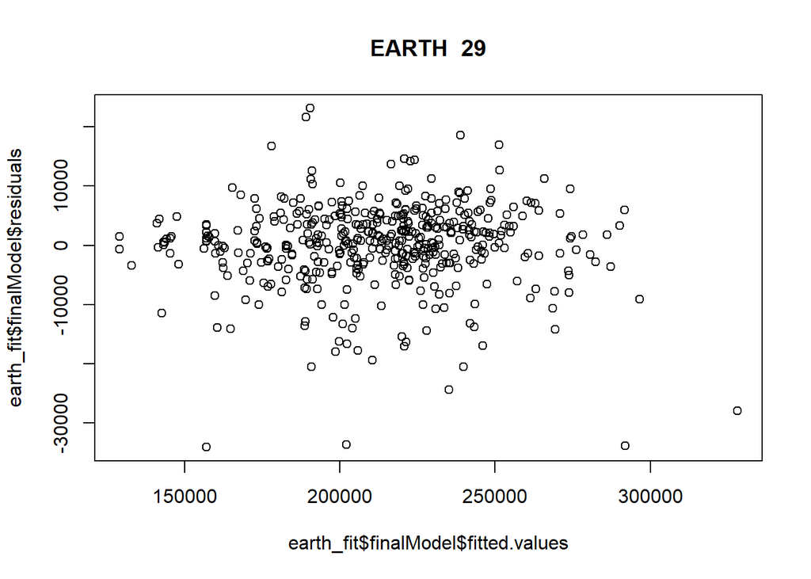

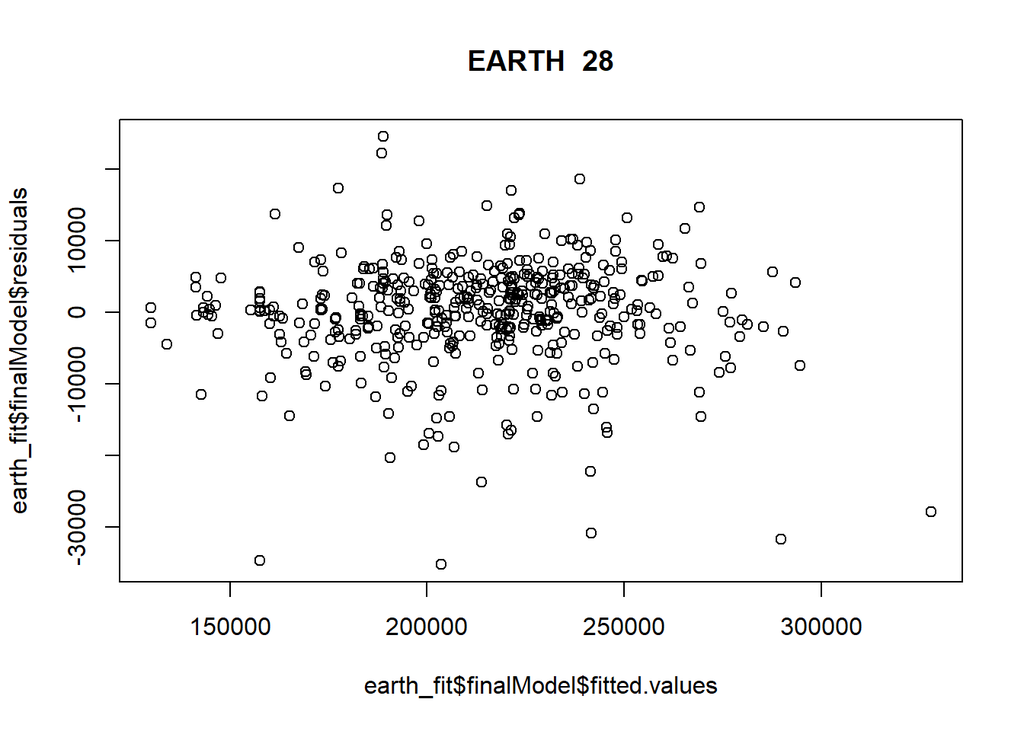

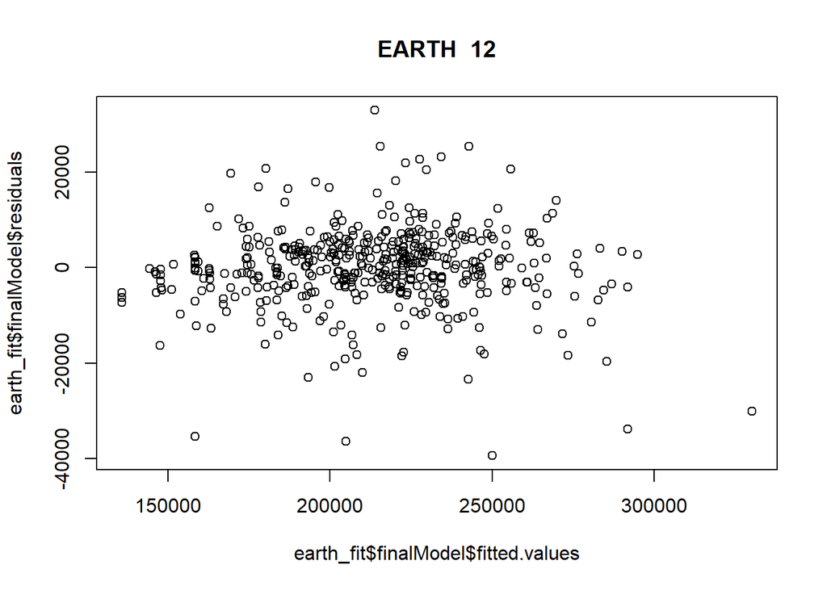

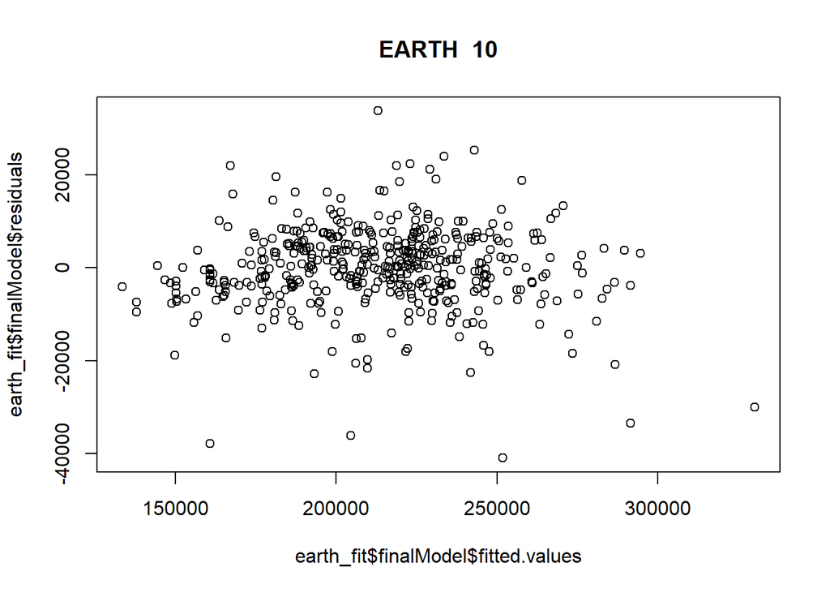

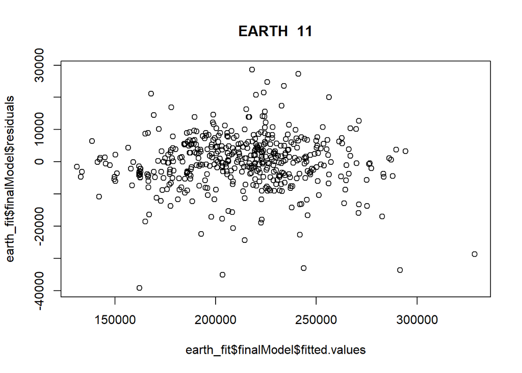

```r
print(earth_results)
```

```
##   mse_train rmse_train mae_train  r2_train rmsesd_train mse_test rmse_test
## 1  71501592   8455.861  5897.809 0.9354747     1655.646 62408710  7899.918
## 2  72728599   8528.106  6028.482 0.9346587     1517.314 63745720  7984.092
## 3  77294453   8791.726  6383.036 0.9298762     1789.813 77481790  8802.374
## 4  78941148   8884.883  6484.523 0.9274371     1797.222 79358279  8908.326
## 5  77884966   8825.246  6280.824 0.9286788     1667.731 71778914  8472.244
##   mae_test   r2_test model num_pred
## 1 5755.121 0.9391656   GLM       29
## 2 5690.440 0.9378624   GLM       28
## 3 6050.680 0.9244728   GLM       12
## 4 6327.881 0.9226436   GLM       10
## 5 6098.314 0.9300318   GLM       11
```

```r
# notes:
# 16       9238.712  0.9211291   6697.297 (nprune,RMSE,R2,MAE)
# warnings with degenerate varaibles (df29,df28), DCK2,CP have zero variance
```

## Model Selection

```r
# # model results:
# linear combinations: lm_results; glm_results
# not linear combination of predictors: rf_results; gam_results; earth_results; svm_results

# combine all model results
all_results <- rbind(lm_results,glm_results,rf_results,gam_results,svm_results,earth_results)
all_results <- all_results %>% select(model,num_pred,everything()) %>% arrange(rmse_test)
all_results
```

| model | num_pred | mse_train | rmse_train | mae_train | r2_train | rmsesd_train | mse_test | rmse_test | mae_test | r2_test |
| --- | --- | --- | --- | --- | --- | --- | --- | --- | --- | --- |
| GLM | 29 | 71501592 | 8455.861 | 5897.809 | 0.935474701 | 1655.64616707936 | 62408710 | 7899.918 | 5755.121 | 0.939165638 |
| GLM | 28 | 72728599 | 8528.106 | 6028.482 | 0.934658694 | 1517.31354964838 | 63745720 | 7984.092 | 5690.440 | 0.937862356 |
| GLM | 29 | 65745010 | 8108.330 | 6184.195 | 0.939094844 | NA | 70575694 | 8400.934 | 6422.924 | 0.931204678 |
| GAM | 29 | 65745010 | 8108.330 | 6184.195 | 0.939094844 | NA | 70575694 | 8400.934 | 6422.924 | 1.000000000 |
| GLM | 28 | 66607672 | 8161.352 | 6280.349 | 0.938295687 | NA | 71071786 | 8430.408 | 6563.108 | 0.930721100 |
| GAM | 28 | 66607672 | 8161.352 | 6280.349 | 0.938295687 | NA | 71071786 | 8430.408 | 6563.108 | 1.000000000 |
| GLM | 11 | 77884966 | 8825.246 | 6280.824 | 0.928678802 | 1667.73146777119 | 71778914 | 8472.244 | 6098.314 | 0.930031811 |
| LM | 29 | 79772584 | 8931.550 | 6872.062 | 0.926491700 | NA | 72580306 | 8519.408 | 6572.864 | 0.929250635 |
| LM | 28 | 79450724 | 8913.514 | 6937.240 | 0.927129273 | NA | 73154189 | 8553.022 | 6712.261 | 0.928691229 |
| GLM | 12 | 77294453 | 8791.726 | 6383.036 | 0.929876193 | 1789.81348935048 | 77481790 | 8802.374 | 6050.680 | 0.924472799 |

[output cut: 20 more lines]

```r
# final model
all_results[7,]
```

|  | model | num_pred | mse_train | rmse_train | mae_train | r2_train | rmsesd_train | mse_test | rmse_test | mae_test | r2_test |
| --- | --- | --- | --- | --- | --- | --- | --- | --- | --- | --- | --- |
| 7 | GLM | 11 | 77884966 | 8825.246 | 6280.824 | 0.9286788 | 1667.73146777119 | 71778914 | 8472.244 | 6098.314 | 0.9300318 |

```r
# summary
n_train; n_test
```

```
## [1] 454
```

```
## [1] 151
```

```r
# nrow(build_data) #608 obs
# nrow(df28) #605 obs, removed outliers
# k number of predictors: 29,28,12,10

# removed binary SPA,RMS out of models
# linear, svm,
```

Multiple models were run for each regression model containing 29,28,12,11,and 10 predictors (num_pred in all_results table). The models with 29 and 28 predictors consistently generated warnings about the degenerate variables warning to interpret results with caution. These models are most likely unstable. The 12 predictor models do not contain any degenerate variables. The 10 predictor models remove the effective frontage and depth property lengths from the 12 predictors (eff_front,eff_depth). The 11 predictor model is generated by adding property id back into the model. This was done to see if the variable contained any predictive information, potentially containing information about property location and adjacencies if the area is part of a community plan. The two binary predictors, RMS and SPA (residential misc shed, spa/hot tub/jacuzzi), were not considered in the linear and SVM models.

## What is the expected accuracy of your approach (R^2 / RMSE / MAE etc.)?

```r
# accuracy of approach
# context
all_results[7,4]/median_value
```

```
## [1] 0.04102857
```

```r
all_results[7,4]/mean_value
```

```
## [1] 0.04145429
```

The earth model with 11 predictor variables has a test RMSE of $8,472.24, approximately 4% of the median home value in the data set.

## Predict the House Values for `results_data`

```r
# transform results_data to match model selected, df11
test_results <- results_data %>%
  mutate(RMS = as.factor(RMS), # change binary variables to factors
         SPA = as.factor(SPA)) %>%
  select('AG', 'DCK', 'LA','LA2', 'OP', 'PA', 'RMS', 'SPA',
         'year_built', 'acres', 'property_id')

test_results[,"property_id"] #2001,2002,2003,2004,2005
```

```
## [1] 2001 2002 2003 2004 2005
```

```r
# earth model
k_pred <- ncol(df11)-1
split = split.data(df11) #x=data frame to split data on
test_pred_final <- rbind(split$test_pred,test_results)

set.seed(694)
control <- trainControl(method='repeatedcv',number=10) #resampling method
tuneLength.num = tune.length.fn(k_pred)


earth_fit = train(x=split$train_pred, y=split$train_resp$value, method="earth",
                    trControl=control, tuneLength=tuneLength.num,
                    preProc = c("center", "scale")) #na.action = na.omit

# predict results_data
value <- predict(earth_fit,newdata=test_pred_final)
# predict(earth_fit,newdata=test_results)
# names(test_results)
value <- value[150:154,]
print(value)
```

```
## [1] 199656.7 214143.4 205331.4 263531.9 223111.0
```

```r
results_data_values <- cbind(results_data,value)
# results_data_values
```